# Pandas

## Overview

## Overview

- Pandas is a package of fast, efficient data analysis tools for Python
- Just as NumPy provides the basic array type plus core array operations, pandas defines some fundamental structures for working with data and endows them with methods that form the first steps of data analysis
- The most important data type defined by pandas is a `DataFrame`, which is an object for storing related columns of data
- In this sense, you can think of a `DataFrame` as analogous to a (highly optimized) Excel spreadsheet, or as a structure for storing the \(X\) matrix in a linear regression

## Overview

- In the same way that NumPy specializes in basic array operations and leaves the rest of scientific tool development to other packages (e.g., SciPy, Matplotlib), pandas focuses on the fundamental data types and their methods, leaving other packages to add more sophisticated statistical functionality
- The strengths of pandas lie in
  - reading in data
  - manipulating rows and columns
  - adjusting indices
  - working with dates and time series
  - sorting, grouping, re-ordering and general data munging
  - dealing with missing values, etc., etc.
- This lecture will provide a basic introduction

## Overview

- Throughout the lecture we will assume that the following imports have taken place

```python
import pandas as pd
import numpy as np
```

## Series

## Series

- Perhaps the two most important data types defined by pandas are the `DataFrame` and `Series` types
- You can think of a `Series` as a "column" of data, such as a collection of observations on a single variable

```python
s = pd.Series(np.random.randn(4), name='daily returns')
s
```

- Here you can imagine the indices `0, 1, 2, 3` as indexing four listed companies, and the values being daily returns on their shares

## Series

- Pandas `Series` are built on top of NumPy arrays, and support many similar operations

```python
s * 100

np.abs(s)
```

- But Series provide more than NumPy arrays
- Not only do they have some additional (statistically oriented) methods

```python
s.describe()
```

- But their indices are more flexible

```python
s.index = ['AMZN', 'AAPL', 'MSFT', 'GOOG']
s
```

## Series

- Viewed in this way, `Series` are like fast, efficient Python dictionaries (with the restriction that the items in the dictionary all have the same type-in this case, floats)
- In fact you can use much of the same syntax as Python dictionaries

```python
s['AMZN']

s['AMZN'] = 0
s

'AAPL' in s
```

## DataFrames

## DataFrames

- As mentioned above a `DataFrame` is somewhat like a spreadsheet, or a structure for storing the data matrix in a regression
- While a `Series` is one individual column of data, a `DataFrame` is all the columns
- Let's look at an example, reading in data from the CSV file `data/test_pwt.csv`.
- Now let's read the data in using pandas' `read_csv` function

```python
df = pd.read_csv('data/test_pwt.csv')
type(df)

df
```

## DataFrames

- We can select particular rows using standard Python array slicing notation

```python
df[2:5]
```

- To select columns, we can pass a list containing the names of the desired columns represented as strings

```python
df[['country', 'tcgdp']]
```

- To select a mix of both we can use the `ix` attribute

```python
df.ix[2:5, ['country', 'tcgdp']]
```

- Let's imagine that we're only interested in population and total GDP (`tcgdp`)

## DataFrames

- One way to strip the data frame `df` down to only these variables is as follows

```python
keep = ['country', 'POP', 'tcgdp']
df = df[keep]
df
```

- Here the index `0, 1,..., 7` is redundant, because we can use the country names as an index
- To do this, first let's pull out the country column using the pop method

## DataFrames

```python
countries = df.pop('country')
type(countries)

countries

df

df.index = countries
df
```

- Let's give the columns slightly better names

```python
df.columns = 'population', 'total GDP'
df
```

## DataFrames

- Population is in thousands, let's revert to single units

```python
df['population'] = df['population'] * 1e3
df
```

- Next we're going to add a column showing real GDP per capita, multiplying by 1,000,000 as we go because total GDP is in millions

```python
df['GDP percap'] = df['total GDP'] * 1e6 / df['population']
df
```

- One of the nice things about pandas `DataFrame` and `Series` objects is that they have methods for plotting and visualization that work through Matplotlib

## DataFrames

- For example, we can easily generate a bar plot of GDP per capita

```python
df['GDP percap'].plot(kind='bar')
import matplotlib.pyplot as plt
plt.show()
```

- At the moment the data frame is ordered alphabetically on the countries-let's change it to GDP per capita

```python
df = df.sort_value(by='GDP percap', ascending=False)
df
```

## DataFrames

[figure not shown]

## On-Line Data Sources

## On-Line Data Sources

- pandas makes it straightforward to query several common Internet databases programmatically
- One particularly important one is FRED - a vast collection of time series data maintained by the St. Louis Fed
- For example, suppose that we are interested in the unemployment rate
- Via FRED, the entire series for the US civilian rate can be downloaded directly by entering this URL into your browser

```
http://research.stlouisfed.org/fred2/series/UNRATE/downloaddata/UNRATE.csv
```

- Equivalently, click [here](http://research.stlouisfed.org/fred2/series/UNRATE/downloaddata/UNRATE.csv)

## On-Line Data Sources

- This request returns a CSV file, which will be handled by your default application for this class of files
- Alternatively, we can access the CSV file from within a Python program
- This can be done with a variety of methods
- We start with a relatively low level method, and then return to pandas

## Accessing Data with urllib.request

- One option is to use `urllib.request`, a standard Python library for requesting data over the Internet
- To begin, try the following code on your computer

```python
import urllib.request
web_page = urllib.request.urlopen('http://cnn.com')
```

- If there's no error message, then the call has succeeded
- If you do get an error, then there are two likely causes
  - You are not connected to the Internet - hopefully this isn't the case
  - Your machine is accessing the Internet through a proxy server, and Python isn't aware of this

## Accessing Data with urllib.request

- Assuming that all is working, you can now proceed to using the `web_page` object returned by the call `urllib.request.urlopen('http://cnn.com')`

```python
web_page.read(100)
```

- The same idea can be used to access the CSV file discussed above

```python
url = 'http://research.stlouisfed.org/fred2/series/UNRATE/downloaddata/UNRATE.csv'
source = urllib.request.urlopen(url)
source.read(100)
```

- We could now write some additional code to parse this text and store it as an array…

## Accessing Data with urllib.request

- But this is unnecessary - pandas' `read_csv` function can handle the task for us

```python
source = urllib2.urlopen(url)
data = pd.read_csv(source, index_col=0, parse_dates=True, header=None)
```

- The data has been read into a pandas DataFrame called `data` that we can now manipulate in the usual way

```python
type(data)

data.head()  # A useful method to get a quick look at a data frame

data.describe()  # Your output might differ slightly
```

## Accessing Data with pandas

- Although it is worth understanding the low level procedures, for the present case pandas can take care of all these messy details
- For example, we can obtain the same unemployment data for the period 2006-2012 inclusive as follows

```python
import pandas.io.data as web
import datetime as dt  # Standard Python date / time library
start, end = dt.datetime(2006, 1, 1), dt.datetime(2012, 12, 31)
data = web.DataReader('UNRATE', 'fred', start, end)
type(data)

data.plot()
import matplotlib.pyplot as plt
plt.show()
```

[output not shown]

## Data from the World Bank

- Let's look at one more example of downloading and manipulating data - this time from the World Bank
- The World Bank collects and organizes data on a huge range of indicators
- For example, here we find data on government debt as a ratio to GDP: http://data.worldbank.org/indicator/GC.DOD.TOTL.GD.ZS/countries
- If you click on "DOWNLOAD DATA" you will be given the option to download the data as an Excel file
- The next program does this for you, parses the data from Excel file to pandas DataFrame, and plots time series for France, Germany, the US and Australia

## Data from the World Bank

```python
import matplotlib.pyplot as plt
from pandas.io.excel import ExcelFile
from urllib.request import urlretrieve
# == Get data and read into file gd.xls == #
wb_data_file_dir = "http://api.worldbank.org/datafiles/"
file_name = "GC.DOD.TOTL.GD.ZS_Indicator_MetaData_en_EXCEL.xls"
url = wb_data_file_dir + file_name
urlretrieve(url, "gd.xls")
# == Parse data into a DataFrame == #
gov_debt_xls = ExcelFile('gd.xls')
govt_debt = gov_debt_xls.parse('Sheet1', index_col=1, na_values=['NA'])
# == Take desired values and plot == #
govt_debt = govt_debt.transpose()
govt_debt = govt_debt[['AUS', 'DEU', 'FRA', 'USA']]
govt_debt = govt_debt[36:]
govt_debt.plot(lw=2)
plt.show()
```

[output not shown]

## Data from the World Bank

- Actually pandas includes high-level functions for downloading World Bank data
- Please see the documents for detail.

## Exercises

## Exercises 1

- Write a program to calculate the percentage price change since the start of the year for the following shares

```
ticker_list = {'INTC': 'Intel',
               'MSFT': 'Microsoft',
               'IBM': 'IBM',
               'BHP': 'BHP',
               'RSH': 'RadioShack',
               'TM': 'Toyota',
               'AAPL': 'Apple',
               'AMZN': 'Amazon',
               'BA': 'Boeing',
               'QCOM': 'Qualcomm',
               'KO': 'Coca-Cola',
               'GOOG': 'Google',
               'SNE': 'Sony',
               'PTR': 'PetroChina'}
```

## Exercises 1

- Use pandas to download the data from Yahoo Finance
- Hint: Try replacing `data = web.DataReader('UNRATE', 'fred', start, end)` with `data = web.DataReader('AAPL', 'yahoo', start, end)` in the code above
- Plot the result as a bar graph, such as this one (of course actual results will vary)

## Exercises 1

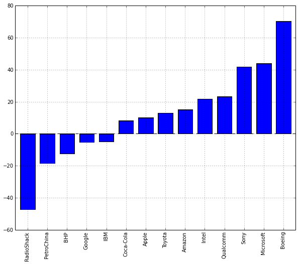